# Tyrosine recombinase subfamily annotation pipeline

## Research Objective 1:

**Annotate tyrosine integrase proteins from MGE databases to subfamilies from Smyshlaev et al. (2021) using SMART reference seqeunces**

Smyshlaev et al’s HMMs are available in their [supplementary data](https://www.embopress.org/action/downloadSupplement?doi=10.15252%2Fmsb.20209880&file=msb20209880-sup-0001-Appendix.pdf). Their HMMs don’t include all the available sequences from the SMART nr database though. We could possibly improve the HMM somewhat by including the extra data.

### SMART reference data

Sequences for each domain subfamily can be downloaded from: http://smart.embl-heidelberg.de/smart/search.cgi?keywords=tyrosine+recombinase. It is a bit tricky to find the link for each sub-family, and from what I can tell, there is no static links for programmatic downloads.

To download the sequences, go to each domain subfamily page (eg. Cyan), click the number of proteins in the domain database: eg. 3164 in “There are 3164 Cyan domains in 3164 proteins in SMART’s nrdb database.”. On the ‘All proteins containing domain’ page, change ‘Action’ to ‘download protein sequences as a FASTA file’. In the next box, select ‘specific domain only’ download the text to `./data/SMART/domains_fasta/`. (We can choose full sequences or specific domain here. Download the full proteins are in `./data/SMART/full_protein_fasta/`.

I collected all the domain reference sequences from SMART integrase subfamilies.

```r
# if (!requireNamespace("BiocManager", quietly = TRUE))
#   install.packages("BiocManager")
# BiocManager::install("Biostrings")
library(Biostrings)
library(tidyverse)

# make dataframe of fastas for each subfamily of domains
ref_domains <-
  tibble(dom_path = Sys.glob('./data/SMART/domain_fasta/*.fasta')) |>
  mutate(
    subfamily = str_remove_all(dom_path,
                               './data/SMART/domain_fasta/|\\.fasta'),
    dom_fasta = map(dom_path, readAAStringSet),
    dom_n = map_int(dom_fasta, ~length(.x)),
    dom_name = map(dom_fasta, ~names(.x)),
    dom_seq = map(dom_fasta, paste)
  ) |>
  # add accession numbers
  left_join(read_csv('./data/SMART/smart_subfamily_ids.csv') |>
              janitor::clean_names() |>
              select(-n_domains),
            by = 'subfamily') |>
  select(subfamily, id, everything())

# write_rds(ref_domains, './data/SMART_domains.rds')
glimpse(ref_domains)
```

```
## Rows: 20
## Columns: 7
## $ subfamily <chr> "Arch1", "Arch2", "Candidate", "Cyan", "IntKX", "Int_BPP-1",…
## $ id        <chr> "SM01446", "SM01456", "SM01447", "SM01452", "SM01450", "SM01…
## $ dom_path  <chr> "./data/SMART/domain_fasta/Arch1.fasta", "./data/SMART/domai…
## $ dom_fasta <list> <<S4 class 'AAStringSet' [package "Biostrings"] with 5 slot…
## $ dom_n     <int> 212, 643, 293, 3164, 687, 2944, 627, 11038, 62, 7015, 18068,…
## $ dom_name  <list> <"smart|Arch1-uniprot|A0A1G7K366|A0A1G7K366_9EURY/1-343 Sit…
## $ dom_seq   <list> <"MSSTRAAPDPDDPVGYFLEDLTYHGKTQRTRAAYERVLRRFEGFLDESEPESATHRD…
```

I compiled all the full AA sequences for the reference integrases from SMART (*i.e.* the full sequences containing the domain sequences above).

```r
# All the full protein sequences for 20 subfamilies from SMART
ref_integrases <-
  tibble(
    prot_path = Sys.glob('./data/SMART/full_protein_fasta/*.fasta')) |>
  mutate(
    subfamily = str_remove_all(
      prot_path, './data/SMART/full_protein_fasta/|\\_proteins.fasta'),
    prot_fasta = map(prot_path, readAAStringSet),
    prot_n = map_int(prot_fasta, ~length(.x)),
    prot_name = map(prot_fasta, ~names(.x)),
    prot_seq = map(prot_fasta, paste)
  ) |>
  # add accession numbers
  left_join(read_csv('./data/SMART/smart_subfamily_ids.csv') |>
              janitor::clean_names() |>
              select(-n_domains),
            by = 'subfamily') |>
  select(subfamily, id, everything())
# write_rds(ref_integrases, './data/SMART_integrases.rds')
glimpse(ref_integrases)
```

```
## Rows: 20
## Columns: 7
## $ subfamily  <chr> "Arch1", "Arch2", "Candidate", "Cyan", "IntKX", "Int_BPP-1"…
## $ id         <chr> "SM01446", "SM01456", "SM01447", "SM01452", "SM01450", "SM0…
## $ prot_path  <chr> "./data/SMART/full_protein_fasta/Arch1_proteins.fasta", "./…
## $ prot_fasta <list> <<S4 class 'AAStringSet' [package "Biostrings"] with 5 slo…
## $ prot_n     <int> 212, 643, 293, 3164, 687, 2944, 627, 11036, 62, 7015, 18068…
## $ prot_name  <list> <"uniprot|A0A1G7K366|A0A1G7K366_9EURY Site-specific recomb…
## $ prot_seq   <list> <"MSSTRAAPDPDDPVGYFLEDLTYHGKTQRTRAAYERVLRRFEGFLDESEPESATHR…
```

I joined the domains and full sequence files into a single huge dataset for all the integrases from SMART.

```r
SMART_db <-
  left_join(ref_domains, ref_integrases, by = c('subfamily', 'id'))

glimpse(SMART_db)
```

```
## Rows: 20
## Columns: 12
## $ subfamily  <chr> "Arch1", "Arch2", "Candidate", "Cyan", "IntKX", "Int_BPP-1"…
## $ id         <chr> "SM01446", "SM01456", "SM01447", "SM01452", "SM01450", "SM0…
## $ dom_path   <chr> "./data/SMART/domain_fasta/Arch1.fasta", "./data/SMART/doma…
## $ dom_fasta  <list> <<S4 class 'AAStringSet' [package "Biostrings"] with 5 slo…
## $ dom_n      <int> 212, 643, 293, 3164, 687, 2944, 627, 11038, 62, 7015, 18068…
## $ dom_name   <list> <"smart|Arch1-uniprot|A0A1G7K366|A0A1G7K366_9EURY/1-343 Si…
## $ dom_seq    <list> <"MSSTRAAPDPDDPVGYFLEDLTYHGKTQRTRAAYERVLRRFEGFLDESEPESATHR…
## $ prot_path  <chr> "./data/SMART/full_protein_fasta/Arch1_proteins.fasta", "./…
## $ prot_fasta <list> <<S4 class 'AAStringSet' [package "Biostrings"] with 5 slo…
## $ prot_n     <int> 212, 643, 293, 3164, 687, 2944, 627, 11036, 62, 7015, 18068…
## $ prot_name  <list> <"uniprot|A0A1G7K366|A0A1G7K366_9EURY Site-specific recomb…
## $ prot_seq   <list> <"MSSTRAAPDPDDPVGYFLEDLTYHGKTQRTRAAYERVLRRFEGFLDESEPESATHR…
```

```r
write_rds(SMART_db, './data/SMART_db.rds', compress = 'gz')

rm(ref_domains, ref_integrases)
```

### Multiple sequence alignment with DECIPHER

I aligned the amino acid sequences for each subfamily with the decipher package with default settings, as follows:

```r
# BiocManager::install("DECIPHER")
library(DECIPHER)

# Create alignment of for each subfamily using decipher;
# reads fasta files from glob of paths
# writes alignments as they finish
make_alignment <- function(name, path){
  message(paste("\n\nAligning subfamily:", name))
  aligned <- AlignSeqs(readAAStringSet(path))
  outpath <- paste0('./data/SMART/domain_alignments/', name, '.aln')
  writeXStringSet(aligned, filepath = outpath)
  return(aligned)
}

# Do all the alignments. Will create .aln files
domains <- read_rds('./data/SMART_domains.rds')
domains <- domains |>
  mutate(aligned = map2(.x = subfamily, .y = path,
                        .f = ~make_alignment(.x,.y)))
```

This creates the aligned fasta files in `./data/SMART/domain_alignments’ as they are finished. The Int_SXT, Int_Tn916, and Xer sub-families take many hours to align.

### Building hidden Markov models

I installed HMMER through conda and created HMMs for each ‘phage integrase’ domain sub-family.

```bash
conda install -c bioconda hmmer

# cd into the `./data/SMART/` folder
mkdir ./domain_hmm

# loop to build model for each subfamily
for file in ./domain_alignments/*.aln
do
  outfile=`echo $file | sed 's/alignments/hmm/g;s/\\.aln/.hmm/g'`
  echo $outfile
  hmmbuild $outfile $file
done

# compile the models into a single hmm database
cat domain_hmm/* > subfamilies.hmm

# compress and index the hmm files
hmmpress subfamilies.hmm
```

I now have a database of domain models that I can use to annotate the SMART domains in any query protein.

### Search for domains in protein sequences with hmmsearch

I did an `hmmsearch` for each subfamily HMM against the collection of SMART integrases. `hmmsearch` takes a single HMM and a set of protein sequences, returning scores for all significant hits in the sequences. Significant hits are found for multiple subfamilies though, so we’ll still need a precise way to discriminate between classes.

```bash
mkdir hmmsearch_res

for hmm in domain_hmm/*;
  do
  outfile=`echo $hmm | sed 's|domain_hmm/||g;s|.hmm|.search|g'`
  echo $outfile
  hmmsearch -o hmmsearch_res/$outfile.raw --tblout hmmsearch_res/$outfile.tbl --domtblout hmmsearch_res/$outfile.domtbl $hmm all_SMART_integrases.fa
done
```

I parsed all the `hmmsearch` results tables and rectangled the data by joining bitscores to protein names & their true subfamilies from the SMART_db.rds dataframe.

```r
# read hmmsearch tblout result
# keep only the best_domain_score column, renamed to the subfamily name
read_hmmersearch_tbl <- function(path){
  read_table(
    file = path,
    na = '-',
    comment = '#',
    col_names =  c(
      "prot_name", "prot_accession",
      "hmm_name", "hmm_accesion",
      "seq_eval", "seq_score", "seq_bias",
      "best_dom_eval", "best_dom_score", "best_dom_bias",
      'domain_n_exp', 'domain_n_reg', 'domain_n_clu', 'domain_n_ov',
      'domain_n_env', 'domain_n_dom', 'domain_n_rep', 'domain_n_inc',
      "description")
  ) |>
    select(prot_name, hmm_name, best_dom_score) |>
    distinct() |>
    pivot_wider(names_from = hmm_name, values_from = best_dom_score) |>
    unnest(cols = c())
}

# All the full protein sequences for 20 subfamilies from SMART
# Unnest and split protein names to match hmmsearch results
integrases <-
  read_rds('./data/SMART_db.rds') |>
  select(subfamily, id, prot_name) |>
  unnest(cols = prot_name) |>
  mutate(temp = trimws(str_extract(prot_name, '.*? ')),
         prot_description = str_remove(prot_name,  '.*?\\s'),
         prot_name = temp) |>
  select(-temp)

# read all the results and join into one table
# join to ref_integrases table
hmmsearches <-
  Sys.glob("./data/SMART/hmmsearch_res/*.search.tbl") |>
  map(read_hmmersearch_tbl) |>
  purrr::reduce(left_join, by = 'prot_name') |>
  right_join(integrases, by = 'prot_name') |>
  select(prot_name, prot_description, subfamily, id, everything())

glimpse(hmmsearches)
```

```
## Rows: 120,549
## Columns: 24
## $ prot_name        <chr> "uniprot|A0A2A2FI84|A0A2A2FI84_9EURY", "uniprot|A0A2G…
## $ prot_description <chr> "Integrase [Halorubrum sp. WN019]", "Integrase [Halor…
## $ subfamily        <chr> "Arch1", "Arch1", "Arch1", "Arch1", "Arch1", "Arch1",…
## $ id               <chr> "SM01446", "SM01446", "SM01446", "SM01446", "SM01446"…
## $ Arch1            <dbl> 612.2, 610.4, 610.1, 609.8, 609.0, 608.5, 608.3, 608.…
## $ Arch2            <dbl> 32.3, 33.4, 32.5, 31.1, 31.5, 32.7, 33.5, 27.6, 31.7,…
## $ Candidate        <dbl> 31.9, 29.8, 33.7, 34.6, 32.3, 32.5, 31.5, 27.1, 31.6,…
## $ Cyan             <dbl> 24.7, 25.2, 24.9, 27.3, 33.0, 26.4, 27.0, 19.0, 35.6,…
## $ IntKX            <dbl> 26.7, 26.3, 24.0, 25.5, 20.1, 27.0, 21.1, 22.9, 20.2,…
## $ `Int_BPP-1`      <dbl> 35.8, 33.5, 35.1, 32.5, 31.9, 34.4, 30.5, 29.4, 32.0,…
## $ Int_Brujita      <dbl> 50.3, 50.0, 49.3, 48.5, 47.3, 53.2, 47.5, 43.6, 49.2,…
## $ Int_CTnDOT       <dbl> 25.5, 21.2, 23.9, 23.3, 19.6, 27.0, 18.9, 20.0, 18.7,…
## $ Int_Des          <dbl> 24.1, 22.9, 22.9, 21.9, 19.2, 22.3, 18.7, 16.7, 19.8,…
## $ Int_P2           <dbl> 37.8, 36.9, 35.8, 36.1, 39.2, 37.2, 37.0, 33.3, 36.8,…
## $ Int_SXT          <dbl> 29.1, 31.1, 31.2, 32.3, 22.2, 28.7, 22.4, 30.5, 26.0,…
## $ Int_Tn916        <dbl> 92.5, 91.7, 94.1, 92.6, 83.3, 92.5, 81.7, 84.3, 85.9,…
## $ Integron         <dbl> 34.0, 32.3, 32.5, 33.1, 32.9, 33.5, 32.7, 32.2, 31.3,…
## $ Myc              <dbl> 28.3, 26.1, 25.4, 31.9, 29.3, 30.2, 27.5, 31.1, 30.8,…
## $ RitA             <dbl> 27.1, 26.9, 27.5, 25.7, 23.6, 26.9, 25.7, 25.2, 22.9,…
## $ RitB             <dbl> 31.1, 29.7, 29.9, 33.2, 25.4, 32.5, 25.9, 35.2, 26.5,…
## $ RitC             <dbl> 37.1, 37.0, 35.9, 37.9, 33.1, 38.3, 32.6, 37.5, 33.1,…
## $ TnpA             <dbl> 29.1, 28.3, 26.9, 32.8, 36.5, 28.5, 34.6, 26.9, 40.0,…
## $ TnpR             <dbl> 40.7, 34.2, 35.2, 39.8, 36.6, 40.1, 34.0, 37.4, 31.1,…
## $ Xer              <dbl> 69.0, 68.0, 67.9, 71.6, 63.7, 67.6, 63.2, 66.9, 65.6,…
```

I plotted the score profiles for each subfamily to explore the discriminative power of the bit-scores. This shows the distribution of scores for a set of sequences from a given subfamily (panel) against each subfamily hmm (y-axis), in terms of the bit scores (x-axis).

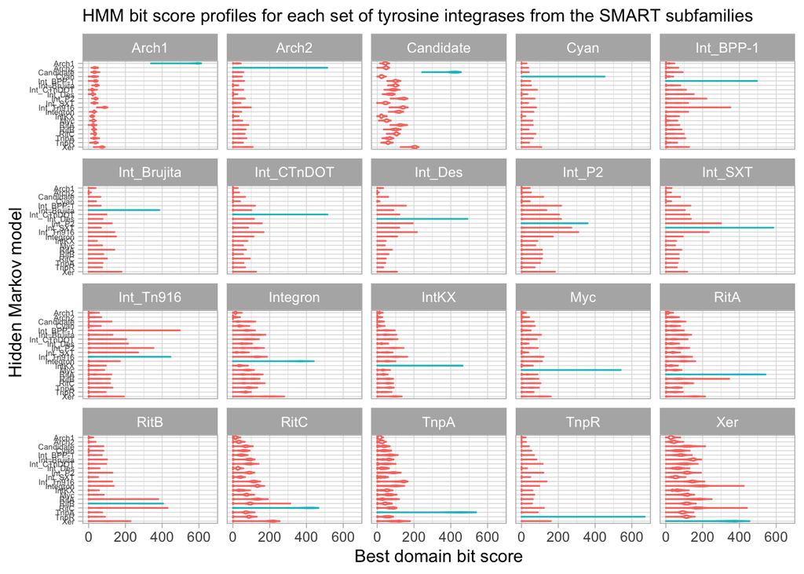

```r
hmmsearches |>
  pivot_longer(cols = c(Arch1:Xer),
               names_to = 'hmm_dom', values_to = 'hmm_score') |>
  mutate(hmm_score = replace_na(hmm_score, 0)) |>
  mutate(highlight = ifelse(hmm_dom == subfamily, T, F)) |>
  ggplot(aes(x = hmm_score, y = fct_rev(hmm_dom),
             color = highlight)) +
  geom_violin() +
  facet_wrap(~subfamily) +
  labs(x = 'Best domain bit score', y = 'Hidden Markov model',
       subtitle = 'HMM bit score profiles for each set of tyrosine integrases from the SMART subfamilies') +
  theme_light() +
  theme(legend.position = 'null',
        axis.text.y = element_text(size = 5))
```

## Pfam HMMs for annotating other domains

It might be useful to add other domains found in tyrosine recombinases, specifically the arm-binding domain and the SAM domains

I downloaded the Pfam-A.seed alignment from ftp.ebi.ac.uk.  
I built the Pfam HMMs database with HMMER.

```
# unpack seed alignments
tar -xvf Pfam-A.seed.gz

# build hmm for each alignment
hmmbuild Pfam-A.hmm Pfam-A.seed

# compress and index the flatfile;
# create 4 binary files .h3m .h3i .h3f and .h3p
hmmpress Pfam-A.hmm
```

Pfam clans??

```r
pfam_clans <-
  read_tsv('./data/Pfam-A/Pfam-A.clans.tsv',
         col_names = c('family_id','clan', 'family_name', 'description'))
```

## CDD batch search

**Input fasta ids (> lines) have to not have anything after a space. And the pipe symbol messes it up too.**  
Batch can handle 4000 queries.

CDD batch search with SMART does not detect the same integrase subfamilies - seems like it hasn’t been updated since these new domains were added.

CDD domains match SMART domains?? Sort of but different names - not sure how they correspond yet.

*SMART has a batch annotation tool, though: ‘You will only get results for sequences that have a match in SMART database, ie. only precomputed results will be displayed’.*

CDD has web api or can use stand-alone RPS-blast with CDD data from ftp.ncbi.nih.gov > cdd.

HTTP GET command to send request

```r
library(httr)
base <- "https://www.ncbi.nlm.nih.gov/Structure/bwrpsb/bwrpsb.cgi?"

# databases: "cdd," "pfam," "smart," "tigrfam," "cog," "kog"
db <- 'db=CDD'

# tdata: hits, aligns, or feats
tdata <- 'tdata=hits'

# data output: rep, std, or full
dmode <- 'dmode=std'

# sequences
# queries <- input_fasta
#
#
# HAVENT figure this API out yet...
```

## Other Figures

### HMM model statistics

The hmm model statistics for each subfamily were recorded from the output of `hmmbuild`

```r
hmms_output <- read_csv('./data/SMART/hmm_output.csv')
glimpse(hmms_output)
```

```
## Rows: 20
## Columns: 6
## $ name     <chr> "Arch1", "Arch2", "Candidate", "Cyan", "IntKX", "Int_BPP-1", …
## $ nseq     <dbl> 212, 643, 293, 3164, 687, 2944, 627, 11038, 62, 7015, 18068, …
## $ alen     <dbl> 417, 515, 360, 974, 395, 875, 486, 2539, 412, 1544, 3117, 587…
## $ mlen     <dbl> 345, 336, 286, 343, 319, 390, 276, 443, 341, 319, 418, 415, 3…
## $ eff_nseq <dbl> 0.85, 2.28, 1.07, 3.84, 1.91, 4.56, 3.13, 9.81, 1.81, 7.35, 5…
## $ `re/pos` <dbl> 0.590, 0.591, 0.589, 0.590, 0.590, 0.590, 0.590, 0.590, 0.590…
```

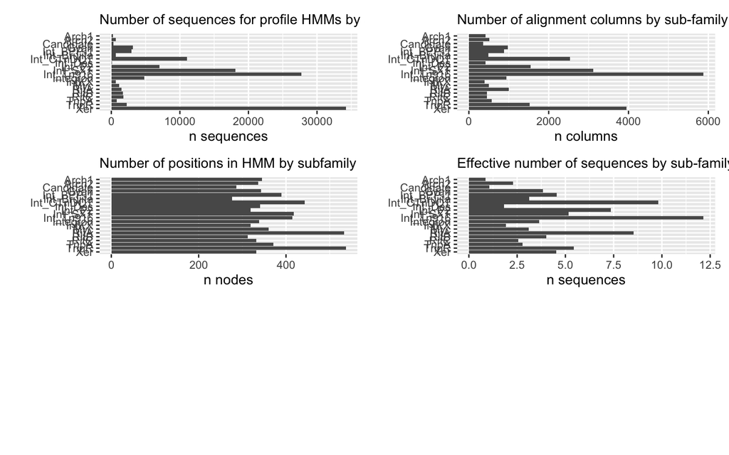

```r
# nseqs
a <- hmms_output |>
  ggplot(aes(nseq, fct_rev(name))) +
  geom_col() +
  labs(y = '', x = 'n sequences',
       subtitle = 'Number of sequences for profile HMMs by sub-family')
# alignment columns
b <- hmms_output |>
  ggplot(aes(alen, fct_rev(name))) +
  geom_col() +
  labs(y = '', x = 'n columns',
       subtitle = 'Number of alignment columns by sub-family')
# number of consensus positions in hmm
c <- hmms_output |>
  ggplot(aes(mlen, fct_rev(name))) +
  geom_col() +
  labs(y = '', x = 'n nodes',
       subtitle = 'Number of positions in HMM by subfamily')
# effective number of sequences
d <- hmms_output |>
  ggplot(aes(eff_nseq, fct_rev(name))) +
  geom_col() +
  labs(y = '', x = 'n sequences',
       subtitle = 'Effective number of sequences by sub-family')

library(patchwork)
((a+b)|(c+d)) + plot_layout(nrow = 4)
```